# Weekly Randomizing Groups - ZOO/BIO 102

Tiago Ribeiro

January 10, 2018

On Fall 2017, I chose to weekly randomize the groups on one of my ZOO/BIO 102 sections, instead of using the approaching of assigning students to fixed groups on the third week of the class. To understand how the students perceived this group assignment approach, I gave them a survey at the end of the semester. Herein, I present the compiled results of the surveys applied to 21 students.

### 1) What did you like about switching groups every week?

```
##  [1] "Getting the chance to meet everyone and work with different people."
##  [2] "It made us get used to talking and working with different people."
##  [3] "It allowed us to get to know everyone better unlike in other classes."
##  [4] "Got a chance to know a lot of people in the class. If a group did not work the best together it was only one class. Kept the class fresh."
##  [5] "I liked that we got to work with different people every week."
##  [6] "I enjoyed meeting new people and getting new opinions/ideas every week."
##  [7] "I liked that we were able to work with different people every week and get exposed to different strengths and weaknesses."
##  [8] "I got to meet everyone in the class and interact with different people."
##  [9] "Being able to share ideas with different people each week was enjoyable."
## [10] "Meeting all of my classmates and working with different people and different learning styles."
## [11] "I liked getting the chance to know more people, working with others and not feeling stuck working people I didn’t like."
## [12] "I liked being able to meet new people and get more viewpoints for each lab."
## [13] "I got to know more of the class."
## [14] "It helps me to focus on the topic/study material."
## [15] "Got to meet new people. Forced us to get out of comfort zone."
## [16] "I loved it. Got to know everyone in the class."
## [17] "Getting to know different people and adjust to different people’s work styles."
## [18] "I liked getting to know almost everybody in the class. It allowed you to talk to new people and learn something from everybody."
## [19] "Meeting new people."
## [20] "Ability to meet more people. Not get stuck with someone you don’t work well with."
## [21] "Working with and getting to know new people."
```

### 2) What did you dislike about switching groups every week?

```
##  [1] "Hard to get really acquainted with anyone specific."
##  [2] "It was spontaneous."
##  [3] "Sometimes people worked better than others. You had to adjust every week based on other people’s level of knowledge/effort."
##  [4] "Unable to build group chemistry. If one group was used through the whole semester every members would know each others strengths and weaknesses and be able to divide work accordingly."
##  [5] "Some groups worked together better than others."
##  [6] "Sometimes in the beginning of the class things were slightly awkward and some people wouldn’t speak up."
##  [7] "Nothing."
##  [8] "Some groups I worked better/more efficiently with than others."
##  [9] "There were times when it would be easy to get stuck with the same group role for multiple consecutive weeks."
## [10] ""
## [11] "Sometimes I really liked my group and didn’t want to change."
## [12] "Sometimes I liked the group I was in the week prior and didn’t want to switch, but otherwise it was fine."
## [13] "I didn’t get to know everyone super well, seemed like everyday was acquaintances. "
## [14] "Usually I can’t work with the people that are familiar to me."
## [15] "It was hard to remember everyone’s name."
## [16] "Didn’t dislike anything about it."
## [17] "Occasionally you’d get with a really good group and sometimes you’d get with a poor group."
## [18] "Having to find the groove of how to work together with you group each week."
## [19] "Not getting to know people well."
## [20] "Had to make dynamic adjustments each week."
## [21] "There wasn’t a consistent amount of effort put forth by some students."
```

### 3) What is your greatest strength when it comes to team learning? What is your greatest

weakness? Describe one way you could make improvements in your own ability to learn with a team this semester.

```
##  [1] "I’m outgoing and can take initiative. I don’t like coming off bossy and I don’t like when people don’t pull their weight. Work on helping with all tasks (touching animals)."
##  [2] "Cooperations. Speaking volume."
##  [3] "Being able to discuss questions thoroughly helps understand concepts better. I tend to take over sometimes, sit back and let others contribute more."
##  [4] "Strength: making sure that everything gets done. Keeping everyone involved. Weakness: sharing my ideas."
##  [5] "I’m usually well prepared and can help with my group with accuracy. My greatest weakness is that sometimes I’m argumentative with other members if we disagree on something. I could be more accepting of other people’s ideas."
##  [6] "My greatest strength is making sure the group is on task and that everyone gets a chance to say what they are thinking. My greatest weakness is not speaking up when I think differently. I was able to build more confidence in myself and speak up more than I normally would."
##  [7] "Greatest strength would be working with others and communicating. Greatest weakness would be not always listening."
##  [8] "Strength = I like to make sure everything is done correctly and within the time frame that is given. Weakness = I am impatient."
##  [9] "My greatest strength is taking information and ideas from other people and applying them to other concepts. My greatest weakness is bringing new information into a subject that can be applied. My ability to learn in a team improved with greater communication at more points during lab activi…
## [10] "I think I am good at taking into consideration what everyone has to say about a topic. Sometimes it can be difficult not to rely on other people to answer questions if I’m feeling tired or something which is something I would want to improve on."
## [11] "I’m good at communicating with others and trying to come to a consensus. If I feel out of my element I can be really quiet and not offer as much to the group. Better preparing myself."
## [12] "My greatest strength in team learning is getting everyone to participate and share their ideas. My greatest weakness in team learning is sometimes being a pushover and letting other group members do most of the work. One way I could improve my ability to learn with teams is to not be afraid…
## [13] "strength: keeping everyone on task. Weakness: getting everyone to talk. Improvement: ask everyone questions."
## [14] "I am a slow reader so I have to read in a very fast and nervous pase."
## [15] "My greatest strength is being open to all ideas, I struggle with making tough decisions. One way I could improve would be to make sure everyone is on the same page before moving on."
## [16] "I’m able to contribute what I know and others are able to contribute too. Sometimes I can’t contribute. Include everyone."
## [17] "I think I’m pretty flexible. I’m able to lead if need be and I’m able to help out and do less facilitating if that’s what is needed. I feel like one weakness was stepping up and being a leader, but over the course of this class it became much easier for me."
## [18] "I think hearing the way somebody your own age explains things is very helpful, compared to individually learning while listening to an instructor."
## [19] "I am a good leader – strength. Sometimes I cannot relinquish leadership – weakness. Let other people lead more."
## [20] "Strength: = ability to step up and lead if need to. Weakness = sometimes do too much/take away from others opportunities. Be cognizant of when my input is needed."
## [21] "Strength: I will never slack off and will put in equal, if not more, effort. Weakness: I tend to be quiet. Take initiative more."
```

The following questions will ask you to answer on a scale from 1-5, and then provide examples that relate to your answer. Please answer all questions with respect to Bio/Zoo 102.

### 4a) To what extent has your ability to work in groups improved?

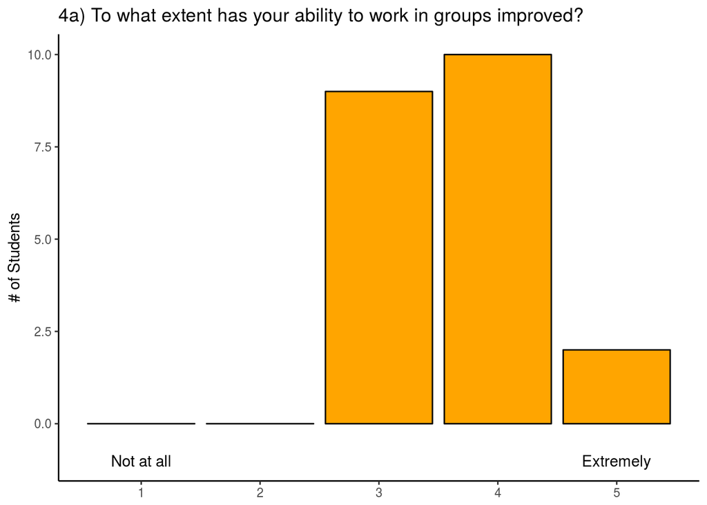

### 4b) Give an example of how your ability to work in groups has changed this semester.

```
##  [1] "Even not knowing people, I branched out and helped initiate conversations."
##  [2] "Better listener."
##  [3] "I used to sit back and let others lead (I was shy) but I now have a greater voice in a group."
##  [4] "Became less she due to working with new people constantly."
##  [5] "I’m better at splitting up tasks with people."
##  [6] "I’ve become more confident in my ability to talk in front of people."
##  [7] "I am able to get ideas and perspectives from different people."
##  [8] "I have learned to interact with different people and utilize each other’s knowledge."
##  [9] "I was able to communicate my own ideas and prior information more readily."
## [10] "I feel like I can learn a lot from my group members when everyone is putting in effort."
## [11] "Not being a science major of any sort, I have learned to have conversations based around science."
## [12] "I am more willing to share my opinion and even lead the group in certain activities."
## [13] "Not as uncomfortable asking people to focus."
## [14] "I’m more willing to express my disagreement and confusion and exchange my thought with others."
## [15] "I feel more open to share with people I just met."
## [16] "I have learned to love meeting new people with learning."
## [17] "I am now much more willing to step up and take leadership positions such as the writing role."
## [18] "I’ve personally become more open and willing to share my thoughts/ideas."
## [19] "Patient with people I didn’t like."
## [20] "Be more aware of whose job is whose. Work together to solve difficult questions."
## [21] "I take more leadership within groups."
```

5. Working in groups can be hard, and often problems in a group have to be identified and solved before the group can move forward.

### 5a) To what extent has your ability to identify problems in a group improved?

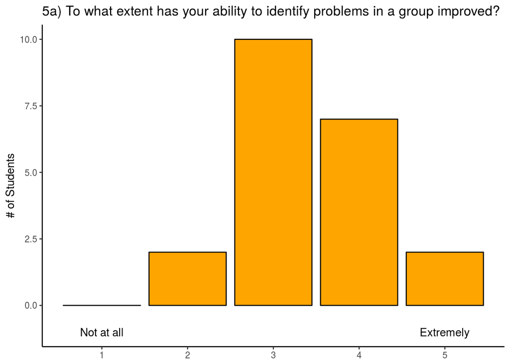

### 5b) Give an example of how your ability to identify problems in a group improved.

```
##  [1] "I did my best to make sure everyone was contributing, although I didn’t really have any issues with anyone."
##  [2] "If someone isn’t contributing."
##  [3] "Working with different people every week allowed new problems. I’ve never experienced to be identified."
##  [4] "Since groups were small it was easy to communicate with each other about what the problem was and how to handle it."
##  [5] "If there’s a disagreement it got addressed."
##  [6] "At one point our group was moving too quick for everyone’s pace so I made sure we went back to review what some missed."
##  [7] "I’m able to communicate better."
##  [8] "When there is an issue, it can be fixed easily and I am aware when I am not satisfied with a group member."
##  [9] "Having instructor feedback readily available made it easier to see if we were going the right direction in some cases and what we needed to do to stay on track."
## [10] "If people don’t agree on an answer the group has work a little harder to figure out what is correct and that everyone understands."
## [11] "Group dynamics can be tricky and it’s important to adapt to those around you in order to try to reach people differently."
## [12] "I noticed that a group doesn’t work as well if not all members are participating."
## [13] "I’m not sure how this is relevant."
## [14] NA
## [15] "I’m not nervous to speak up if I think something is wrong."
## [16] "I am able to know when the group doesn’t understand things."
## [17] "I just think I became a better communicator and that helped solve problems."
## [18] "I’ve never really had a major problem in a group. I guess just not getting suck on one problem and moving on."
## [19] NA
## [20] "People not helping: encourage them to participate."
## [21] "I can quickly problem-solve and figure out an effective solution."
```

### 5c) To what extent has your ability to solve problems in a group improved?

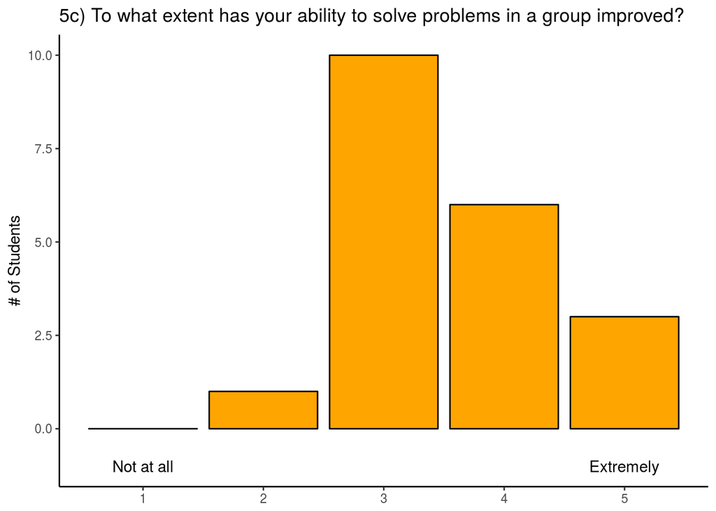

### 5d) Give an example of how your ability to identify problems in a group improved.

```
##  [1] "Didn’t really encounter issues within my groups."
##  [2] "Efficient thinking."
##  [3] "I would notice when people maybe weren’t contributing much or at all, but I would avoid confrontation."
##  [4] "If there are several different opinions in the group, all are shared and analyzed in a respectful manner to find the most correct one."
##  [5] "By discussing the disagreement we were able to work through it and come to a common conclussion."
##  [6] "There was a time when I had a different opinion from someone in my group, we went back and forth giving opinions until finally we made a collective decision."
##  [7] "We work together to get the answers."
##  [8] "Working together every week on a new topic and <???> completing the pre-lab has made me prepared for the problems we need to answer."
##  [9] "It became easier to find issues in out group work and to explain what needed to be done to correct it."
## [10] "Going back and looking over the material and asking for help when needed is an example of the problem solving I have witnessed throughout this semester.."
## [11] "Talking through things that not everyone agrees on in order to come to the best and most accurate solution."
## [12] "When I notice there is a problem in a group, such as a lack of participation, then I make sure that everyone is included from that point on without criticizing my members."
## [13] "Relying on everyone’s knowledge."
## [14] "Each of us give reason which supports our claims and we compare to see which one makes more sense when disagreement occurs."
## [15] "I learned to ask for help when I need it."
## [16] "I am a lot better at listening to others ideas."
## [17] "I just think I became a better communicator and that helped solve problems."
## [18] NA
## [19] "Easy to identify negative leader in group."
## [20] NA
## [21] "It improved through being able to take better observations of the group and to step back and evaluate the situation at hand."
```

### 6a) How much you believe that your ability to work in groups would have improved if you had been assigned to a fixed group at the beginning of the semester?

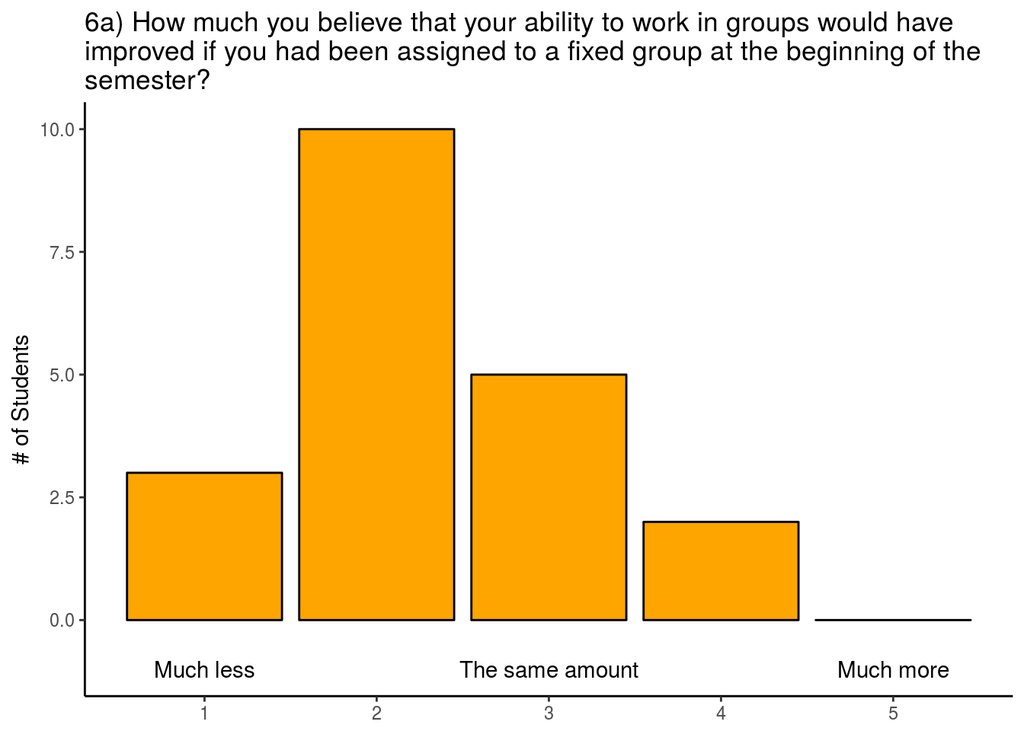

### 6b) Why?

```
##  [1] "Maybe a little more because working with and being around the same people presents the possibility of issues more and you’d be more focused on resolving them if you had to continue to work with the same people."
##  [2] "Less, diverse group play."
##  [3] "You’d get used to the people you were working with and probably experience the same thing every week. Working with new people every week allowed new challenges."
##  [4] "Learning to adapt to the new group each week required much more effort in regards to team learning and team work."
##  [5] "When you switch groups you get to work with a variety of different people so you can learn to work with a variety of people."
##  [6] "The same amount because while it might have been more comfortable we would have gotten off task more."
##  [7] "I feel that by being exposed to different people with different strengths and weaknesses every week really allowed for my problem solving and communication skills to improve."
##  [8] "Because everyone in this class is capable of solving the problems presented so it doesn’t matter if we switch groups or not."
##  [9] "Working with the same group can limit how much the activities can change."
## [10] "I think I would use the same methods to problem solve."
## [11] "It could be more or less because I could’ve had a fixed group that was difficult to work with but switching every week also helps to adapt to the situation presented."
## [12] "I feel like a change in group members allows one to better adapt to more team learning problems and learning styles, but if groups were fixed, then you would get used to your members."
## [13] "I’m not sure. I’ve developed more skills working with strangers this semester. Having a fixed group, I would probably have acquainted better with the people, working the friends not strangers."
## [14] "Being in a more comfortable environment very stimulate my thought, and I may be more willing to talk."
## [15] "I’m pretty consistent when it comes to learning. As long as my group wasn’t composed of my best friends."
## [16] "Being with new people allows me to experience how different types of people interact and how to cope with those interactions while trying to achieve a goal."
## [17] "I think that on day one the roles would have been identified. So maybe if one person was more outgoing they would be stuck leading the whole year and vice versa."
## [18] "You would get used to the same people doing the same task and/or having more or less knowledge than others. Switching groups forces you to come prepared because you don’t know who you’ll be with."
## [19] "If the group was good you’d never have to solve problem, if group was bad, it may lead to long term negativity."
## [20] "Although I would have gotten to know them better, learn how to work with them, I wouldn’t have had to learn how to work with different types of people."
## [21] "You do not have the opportunity to work with different types of people. The people in the group will likely have a set task and the group would remain the same."
```

### 7a) Based on your experiences this semester in Bio/Zoo 102, in the future, how frequently do you think lab courses should ask students to switch groups?

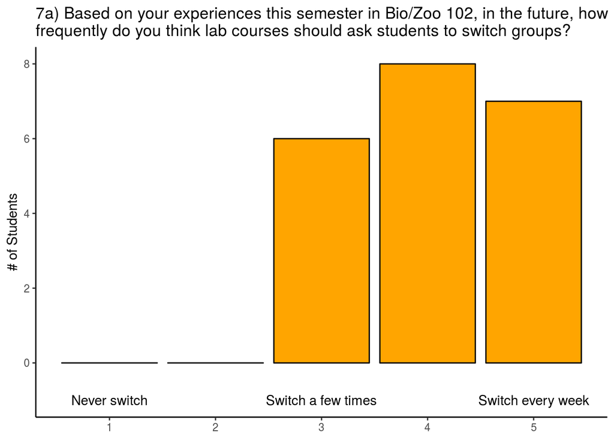

### 7b) Why?

```
##  [1] "I think it was great meeting people and being able to work with almost everyone, but being with the same groups sometimes allows for making stronger connections."
##  [2] "So it’s not too much, but just enough."
##  [3] "Good experiences. Helped improve learning."
##  [4] "Fine balance between not allowing people to become too comfortable with their groups and allowing each individual group to grow as a whole throughout the semester."
##  [5] "If you’re having trouble with a certain group it allows you not to be stuck with them, it introduces you to everyone in the class, and you work with different kinds of people."
##  [6] "I believe it is good for students to be pushed outside their comfort zones."
##  [7] "I enjoyed switching every week."
##  [8] "I like some groups/people more than others, you just bond well with others more than everyone in the class so it would be nice to switch sometimes only."
##  [9] "Listening to more people made applying new practices in team work more effective."
## [10] "Working with new people ensure that you can’t always get stuck with someone you don’t like working with."
## [11] "I would rather switch groups."
## [12] "I think groups should be switched relatively frequently so that everyone gets used to dealing with more kinds of people."
## [13] "Maybe 3 times a semester so one can learn to develop stronger relationships while also learning to work with strangers."
## [14] "In order to form a more comfortable environment, I’d suggest a fixed group, but switches should be applied to prevent the casual talks."
## [15] "I don’t know if it would improve productivity, but it helps introduce people and forces us to interact with people we haven’t met yet."
## [16] "I think it really helped me feel closer to the whole class."
## [17] "Helps you meet more people and communicate in different settings."
## [18] "You take something from everyone. You can learn from everyone."
## [19] "I liked this way a ton."
## [20] "Get to know people better, but still have the opportunity to work with different types of people."
## [21] "Switch to optimize your team-working abilities but maybe every other week so there is more opportunity to make personal connections."
```

### 8) Is there any other feedback you would like to give regarding the way groups were assigned every week?

```
##  [1] "Nope."
##  [2] "No."
##  [3] ""
##  [4] ""
##  [5] "Although it was meant to be random, I did end up working with several people many times and some never."
##  [6] "I enjoyed working with everyone and I loved this class!"
##  [7] "Nope."
##  [8] "Nope"
##  [9] ""
## [10] ""
## [11] ""
## [12] ""
## [13] "I wasn’t a fan of changing everyweek."
## [14] ""
## [15] ""
## [16] ""
## [17] "I’d recommend continuing it."
## [18] ""
## [19] ""
## [20] ""
## [21] "Maybe ask the students what they would prefer."
```